# 4545 Team League: Season 2

[figure not shown]

### Overview

This [season’s](https://www.lichess4545.com/team4545/season/2/summary/) games were played between 15 January 2016 and 14 March 2016.

138 players participated, 115 (83%) of whom were new to the league.

21.75 teams played 87 matches over the season’s eight weeks. 14 matches (16%) were drawn, and 34 (39%) were won by just a single point.

White won 192 games (47.8%), 52 games (12.9%) were drawn, and Black won 151 games (37.6%). The right-hand chart shows game results by colour for each board or average rating band.[^2]

[figure not shown]

### Final standings

*Team rosters ordered by number of games played (shown in brackets)*

1st place

[Sicilian Dragons](https://www.lichess4545.com/team4545/season/2/team/5/)

2nd place

[Olympic Team of North Korea](https://www.lichess4545.com/team4545/season/2/team/16/)

3rd place

[The Grand Wazoo](https://www.lichess4545.com/team4545/season/2/team/20/)

| Gold | Silver | Bronze |
| --- | --- | --- |
| Jaivl (8) | Crunchyalex (8) | fradtheimpaler (8) |
| Matuiss2 (8) | kimaga (8) | GnarlyGoat (8) |
| Scarff (8) | Lrdwhyt (8) | JPTriton (8) |
| somethingpretentious (8) | hillrp (7) | thibault (8) |
| Immortality (5) | MadLoKi (7) | Unihedron (8) |
| Sasho21 (1) | Tassel (1) |  |

#### How the title race played out

[figure not shown]

**Match stories**

See the twists and turns in every match this season through these PDF visualisations…assuming they’ve already been created and uploaded. [Source script](https://github.com/rahulan-c/lichess4545-stats/blob/main/scripts/plot_match_story.R).

Round 1 | Round 2 | Round 3 | Round 4 | Round 5 | Round 6 | Round 7 | Round 8

### Top players 🎩

#### Board medals

Here are the top player performances on each board (minimum 5 games played).[^3]

| Board | Player(s) | Games | Points | Board Perf. |
| --- | --- | --- | --- | --- |
| 1 | Matuiss2 | 8 | 7 | 2360.875 |
| 1 | Pitrinu | 8 | 6.5 | 2263.75 |
| 1 | Crunchyalex | 7 | 5 | 2189.85714285714 |
| 2 | jlustig555 | 6 | 5.5 | 2228.33333333333 |
| 2 | theino | 7 | 6 | 2177 |
| 2 | ecstaticbroccoli | 6 | 5 | 2108.66666666667 |
| 3 | xaviar | 5 | 4.5 | 2076.2 |
| 3 | Unihedron | 8 | 7 | 2031.75 |
| 3 | EsolcNeveton | 6 | 4 | 1822.33333333333 |
| 4 | Jaivl | 7 | 7 | 2456.28571428571 |

[output cut: 5 more lines]

#### Best scorers

Here’s everyone who achieved a plus score of +5 or higher this season[^4]:

**Jaivl** (7.5/8), **Matuiss2** (7/8), **Unihedron** (7/8), **jlustig555** (5.5/6), **Pitrinu** (6.5/8), **theino** (6/7)

Players with plus scores of +6 or better get the **Ace** award.

### Stats - overview

#### Timing 📊

[figure not shown]

#### Length 📊

[figure not shown]

#### Most moves

*Includes games ranked at or above the 90th percentile by number of moves.*

| Rank | Players / Link | Date | Moves |
| --- | --- | --- | --- |
| 1 | cheese111 - ubernoobek | Sun 14 Feb 2016 | 104 |
| 2 | DurchNachtUndWind - CaptNCarter | Sun 6 Mar 2016 | 83 |
| 3 | steiger07 - sahkal | Thu 10 Mar 2016 | 82 |
| 4 | SheepNL - Matuiss2 | Sat 13 Feb 2016 | 81 |
| 4 | GMPraveen - Alex_1987 | Fri 12 Feb 2016 | 81 |
| 5 | thisISSmax - bramminator | Sun 31 Jan 2016 | 75 |
| 5 | RaitonvsFuuton - fradtheimpaler | Sun 31 Jan 2016 | 75 |
| 6 | sahkal - Atrophied | Sun 17 Jan 2016 | 74 |
| 7 | somethingpretentious - kimaga | Sat 27 Feb 2016 | 73 |
| 7 | resonantpillow - GMPraveen | Mon 22 Feb 2016 | 73 |

[output cut: 34 more lines]

#### Longest games

*Includes games ranked at or above the 90th percentile by total clock time.*[^5]

| Rank | Players / Link | Date | Total time |
| --- | --- | --- | --- |
| 1 | ubernoobek - bodhmall | Sat 5 Mar 2016 | 0h 0m 0s |
| 1 | Zouave - kingscrusher-fan | Sat 5 Mar 2016 | 0h 0m 0s |
| 1 | kimaga - ecstaticbroccoli | Fri 4 Mar 2016 | 0h 0m 0s |
| 1 | revoof - CTORH | Fri 4 Mar 2016 | 0h 0m 0s |
| 1 | thetasquared - Djcrisce | Fri 4 Mar 2016 | 0h 0m 0s |
| 1 | fourtwenty - explodingllama | Thu 3 Mar 2016 | 0h 0m 0s |
| 1 | HoxHound - plasmacat | Thu 3 Mar 2016 | 0h 0m 0s |
| 1 | Alex_1987 - GnarlyGoat | Thu 3 Mar 2016 | 0h 0m 0s |
| 1 | riemannn - Thepawnslayer | Wed 2 Mar 2016 | 0h 0m 0s |
| 1 | sahkal - frogger | Tue 1 Mar 2016 | 0h 0m 0s |

[output cut: 34 more lines]

### Stats - by board/rating

#### ACPL and blunder rate 📊

[figure not shown]

#### Lowest combined ACPL

The games with the lowest combined ACPL (including draws).

| Board | Players / Link | Result | Sum ACPL | Date |
| --- | --- | --- | --- | --- |
| 1 | GMPraveen - Alex_1987 | 1/2-1/2 | 8 | Fri 12 Feb 2016 |
| 2 | rreyv - iHateRBF | 1/2-1/2 | 15 | Fri 26 Feb 2016 |
| 3 | Jaivl - Nytik | 1/2-1/2 | 12 | Wed 2 Mar 2016 |
| 4 | LoveTriangle - MadLoKi | 1/2-1/2 | 8 | Sun 31 Jan 2016 |
| 5 | endrawes0 - asifmallik | 1/2-1/2 | 26 | Sun 21 Feb 2016 |

#### Decisive games only

The *decisive* games with the lowest combined ACPL.

| Board | Players / Link | Result | Sum ACPL | Date |
| --- | --- | --- | --- | --- |
| 1 | Matuiss2 - Sonata2 | 0-1 | 22 | Sun 6 Mar 2016 |
| 2 | plasmacat - rreyv | 1-0 | 26 | Sat 12 Mar 2016 |
| 3 | EsolcNeveton - thisISSmax | 1-0 | 25 | Sun 13 Mar 2016 |
| 4 | dimasikson - CarlosMagnussen | 1-0 | 30 | Sat 13 Feb 2016 |
| 5 | flandoo - tnan123 | 1-0 | 41 | Sat 30 Jan 2016 |

### Openings

#### First moves 📊

[figure not shown]

#### Top openings

All openings played in the season, excluding variations.

| rank | opening.broad | games | perc_w | white_wins | draws | black_wins | mean_eval_after_15 | mean_rating |
| --- | --- | --- | --- | --- | --- | --- | --- | --- |
| 1 | Sicilian Defense | 65 | 59.2307692307692 | 50.7692307692308 | 16.9230769230769 | 32.3076923076923 | 0.34953125 | 1767.57692307692 |
| 2 | Slav Defense | 33 | 66.6666666666667 | 60.6060606060606 | 12.1212121212121 | 27.2727272727273 | 0.1246875 | 1693.25757575758 |
| 3 | French Defense | 31 | 56.4516129032258 | 54.8387096774194 | 3.2258064516129 | 41.9354838709677 | 0.292666666666667 | 1816.24193548387 |
| 4 | English Opening | 23 | 52.1739130434783 | 47.8260869565217 | 8.69565217391304 | 43.4782608695652 | 0.115652173913043 | 1730.69565217391 |
| 5 | King's Indian Defense | 21 | 57.1428571428571 | 52.3809523809524 | 9.52380952380952 | 38.0952380952381 | 0.214285714285714 | 1829.14285714286 |
| 6 | Queen's Gambit Declined | 20 | 45 | 45 | 0 | 55 | 0.076 | 1653.375 |
| 6 | Ruy Lopez | 20 | 62.5 | 55 | 15 | 30 | 0.620526315789474 | 1701.85 |
| 7 | Caro-Kann Defense | 18 | 33.3333333333333 | 22.2222222222222 | 22.2222222222222 | 55.5555555555556 | 0.189411764705882 | 1675.27777777778 |
| 7 | Nimzo-Indian Defense | 18 | 55.5555555555556 | 50 | 11.1111111111111 | 38.8888888888889 | 0.348333333333333 | 1799.47222222222 |
| 8 | Scandinavian Defense | 17 | 32.3529411764706 | 29.4117647058824 | 5.88235294117647 | 64.7058823529412 | 0.397647058823529 | 1738.47058823529 |

[output cut: 41 more lines]

#### Best for White

White’s top-scoring openings, excluding variations. *Minimum 10 games played.*

| rank | opening.broad | games | perc_w | white_wins | draws | black_wins | mean_eval_after_15 | mean_rating |
| --- | --- | --- | --- | --- | --- | --- | --- | --- |
| 1 | Slav Defense | 33 | 66.6666666666667 | 60.6060606060606 | 12.1212121212121 | 27.2727272727273 | 0.1246875 | 1693.25757575758 |
| 2 | Ruy Lopez | 20 | 62.5 | 55 | 15 | 30 | 0.620526315789474 | 1701.85 |
| 3 | Sicilian Defense | 65 | 59.2307692307692 | 50.7692307692308 | 16.9230769230769 | 32.3076923076923 | 0.34953125 | 1767.57692307692 |
| 4 | King's Indian Defense | 21 | 57.1428571428571 | 52.3809523809524 | 9.52380952380952 | 38.0952380952381 | 0.214285714285714 | 1829.14285714286 |
| 5 | French Defense | 31 | 56.4516129032258 | 54.8387096774194 | 3.2258064516129 | 41.9354838709677 | 0.292666666666667 | 1816.24193548387 |
| 6 | Nimzo-Indian Defense | 18 | 55.5555555555556 | 50 | 11.1111111111111 | 38.8888888888889 | 0.348333333333333 | 1799.47222222222 |
| 7 | Italian Game | 11 | 54.5454545454545 | 45.4545454545455 | 18.1818181818182 | 36.3636363636364 | 0.153 | 1634.40909090909 |
| 8 | English Opening | 23 | 52.1739130434783 | 47.8260869565217 | 8.69565217391304 | 43.4782608695652 | 0.115652173913043 | 1730.69565217391 |
| 9 | Grünfeld Defense | 11 | 50 | 45.4545454545455 | 9.09090909090909 | 45.4545454545455 | 0.202727272727273 | 1773.90909090909 |
| 10 | Queen's Gambit Declined | 20 | 45 | 45 | 0 | 55 | 0.076 | 1653.375 |

[output cut: 3 more lines]

#### Best for Black

Black’s top-scoring openings, excluding variations. *Minimum 10 games played.*

| rank | opening.broad | games | perc_b | black_wins | draws | white_wins | mean_eval_after_15 | mean_rating |
| --- | --- | --- | --- | --- | --- | --- | --- | --- |
| 1 | Scandinavian Defense | 17 | 67.6470588235294 | 64.7058823529412 | 5.88235294117647 | 29.4117647058824 | 0.397647058823529 | 1738.47058823529 |
| 2 | Caro-Kann Defense | 18 | 66.6666666666667 | 55.5555555555556 | 22.2222222222222 | 22.2222222222222 | 0.189411764705882 | 1675.27777777778 |
| 2 | Queen's Pawn Game | 12 | 66.6666666666667 | 66.6666666666667 | 0 | 33.3333333333333 | 0.259090909090909 | 1709.45833333333 |
| 3 | Queen's Gambit Declined | 20 | 55 | 55 | 0 | 45 | 0.076 | 1653.375 |
| 4 | Grünfeld Defense | 11 | 50 | 45.4545454545455 | 9.09090909090909 | 45.4545454545455 | 0.202727272727273 | 1773.90909090909 |
| 5 | English Opening | 23 | 47.8260869565217 | 43.4782608695652 | 8.69565217391304 | 47.8260869565217 | 0.115652173913043 | 1730.69565217391 |
| 6 | Italian Game | 11 | 45.4545454545455 | 36.3636363636364 | 18.1818181818182 | 45.4545454545455 | 0.153 | 1634.40909090909 |
| 7 | Nimzo-Indian Defense | 18 | 44.4444444444444 | 38.8888888888889 | 11.1111111111111 | 50 | 0.348333333333333 | 1799.47222222222 |
| 8 | French Defense | 31 | 43.5483870967742 | 41.9354838709677 | 3.2258064516129 | 54.8387096774194 | 0.292666666666667 | 1816.24193548387 |
| 9 | King's Indian Defense | 21 | 42.8571428571429 | 38.0952380952381 | 9.52380952380952 | 52.3809523809524 | 0.214285714285714 | 1829.14285714286 |

[output cut: 3 more lines]

#### Top gambits

The most played gambits over the season.[^6]

| Rank | Name | Games | White score (%) |
| --- | --- | --- | --- |
| 1 | Budapest Defense | 3 | 0.333333333333333 |
| 2 | Queen's Gambit Accepted | 2 | 0.75 |
| 3 | King's Gambit | 2 | 0.5 |
| 4 | Benko Gambit | 1 | 1 |
| 4 | Greco Gambit | 1 | 1 |
| 4 | King Knight's Gambit | 1 | 1 |
| 4 | Ruy Lopez: Marshall Attack | 1 | 1 |
| 4 | Schulz Gambit | 1 | 1 |
| 4 | Smith-Morra Gambit | 1 | 1 |
| 5 | Evans Gambit | 1 | 0 |

[output cut: 3 more lines]

#### Gambiteers 🤺

The players who enjoyed the most success when playing gambits.[^7] *Includes everyone who scored at least 50 per cent across at least two gambit games.*

| Rank | Player | Games | % Score | W | B | Choices |
| --- | --- | --- | --- | --- | --- | --- |
| 1 | crabbypat | 2 | 100 | 1 | 1 | Ruy Lopez: Marshall Attack, Greco Gambit |

### Openings sunburst 🌞

Click on the image below to see a sunburst plot of all openings played in the season.

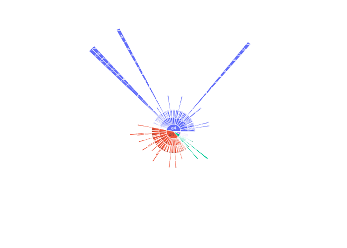

### Awards 🏆

Assorted awards to celebrate the season. See the footnote for more details about each award.[^8]

| Award | Name / Description | Winner(s) | Runner(s)-up |
| --- | --- | --- | --- |
| x | Aces | Jaivl, Matuiss2, Unihedron |  |
| x | Archbishop of Accuracy | rreyv | Jaivl, Pitrinu |
| x | Awesome Alt | chill5555, Qade, scottm91, theino, thetasquared | Aianryu, CheapEndgameTricks, ChessedToImpress, Clerseri, dnowchess, Iamsostupid, kansashandle, KingShrink, kirylb, rnstkn11, Sasho21, shammies, Tassel, Wrazer (1) |
| x | Bullet Boss |  |  |
| x | David Award | chill5555 | rreyv, llimllib |
| x | Egalitarian Award | The Stale Maids |  |
| x | Gambit Guru | crabbypat | NA |
| x | Giri Award | Nytik, ubernoobek |  |
| x | Grischuk's Cousin |  |  |
| x | Houdini Award | fradtheimpaler | Braffin, shetoo |

[output cut: 10 more lines]

- Fortune favoured **Olympic Team of North Korea**, who managed to win **4** matches by a single point!
- Conversely, **Beavis and Butt-vinik** must be ruing their luck after suffering **5** agonising single-point defeats.

### Stats - tables 📚

Tons of detailed stats for your reading pleasure. All tables in this section are sortable and searchable - feel free to explore!

#### Team statistics

Check out various team stats in the table below. Hover over the abbreviated headers to see their full names.

| rank | Team | games | points | pts_nonforf | wins | draws | losses | players | avg_moves | ACPL | blunder_pc |
| --- | --- | --- | --- | --- | --- | --- | --- | --- | --- | --- | --- |
| 1 | Sicilian Dragons | 38 | 27.5 | 25 | 23 | 4 | 11 | 6 | 39.4473684210526 | 29.0593729152768 | 1.66777851901268 |
| 2 | Olympic Team of North Korea | 39 | 24 | 23 | 20 | 6 | 13 | 6 | 35.8205128205128 | 33.5647816750179 | 3.07802433786686 |
| 3 | The Grand Wazoo | 40 | 22.5 | 22.5 | 21 | 3 | 16 | 5 | 38.475 | 34.6374269005848 | 2.79402209226771 |
| 4 | Kingslayers | 38 | 24 | 21 | 21 | 0 | 17 | 5 | 36.5263157894737 | 28.7312680115274 | 2.6657060518732 |
| 5 | Knights of the Square Table | 37 | 21.5 | 19 | 16 | 6 | 15 | 6 | 37.1081081081081 | 29.0262199563001 | 2.91332847778587 |
| 6 | E4 Effort | 37 | 20.5 | 21.5 | 19 | 5 | 13 | 6 | 39.1351351351351 | 27.3259668508287 | 1.51933701657459 |
| 7 | That's Tal Folks | 35 | 23 | 20 | 18 | 4 | 13 | 7 | 40.6571428571429 | 33.7160927617709 | 2.67041461700632 |
| 8 | The Stale Maids | 37 | 21 | 18 | 16 | 4 | 17 | 5 | 35.7297297297297 | 34.9553706505295 | 4.31164901664145 |
| 9 | Other People's Pieces (O.P.P.) | 38 | 20.5 | 20.5 | 18 | 5 | 15 | 8 | 38.3947368421053 | 33.7614804660727 | 2.3989033584647 |
| 10 | Mighty Morphin' Pawn Arrangers | 35 | 20 | 21 | 17 | 8 | 10 | 7 | 38.1428571428571 | 35.7955056179775 | 2.47191011235955 |

[output cut: 12 more lines]

#### Best performances / highest accuracy

##### Best relative performances

This table shows players’ *relative* performance ratings – that is, their performance rating over the season minus their initial rating before their first game.[^9] *Includes everyone with a positive relative performance rating over at least five games.*

| # | Player | Games | W | D | L | Initial | Perf | Diff. |
| --- | --- | --- | --- | --- | --- | --- | --- | --- |
| 1 | jlustig555 | 6 | 5 | 1 | 0 | 1761 | 2228.33333333333 | 467.333333333333 |
| 2 | Jaivl | 8 | 7 | 1 | 0 | 1673 | 2112.875 | 439.875 |
| 3 | theino | 7 | 6 | 0 | 1 | 1783 | 2177 | 394 |
| 4 | xaviar | 5 | 4 | 1 | 0 | 1691 | 2076.2 | 385.2 |
| 5 | Cenotaph5 | 6 | 5 | 0 | 1 | 1451 | 1815.83333333333 | 364.833333333333 |
| 6 | resonantpillow | 6 | 4 | 1 | 1 | 1851 | 2205.83333333333 | 354.833333333333 |
| 7 | Immortality | 5 | 4 | 0 | 1 | 1453 | 1802.2 | 349.2 |
| 8 | Unihedron | 8 | 7 | 0 | 1 | 1714 | 2031.75 | 317.75 |
| 9 | Crunchyalex | 8 | 5 | 2 | 1 | 1888 | 2191.75 | 303.75 |
| 10 | ecstaticbroccoli | 6 | 5 | 0 | 1 | 1825 | 2108.66666666667 | 283.666666666667 |

[output cut: 37 more lines]

##### Lowest ACPL

All players who played at least five games and achieved a season ACPL in the 20th percentile or below. Note that ‘season ACPL’ differs from Lichess game-wide ACPL figures, as it excludes opening moves as well as most moves played in objectively decided positions. See the footnote for full details.[^10] ACPLs based on Lichess’s published figures are provided for comparison purposes.

| Rank | Player | Games | Season ACPL | Lichess ACPL |
| --- | --- | --- | --- | --- |
| 1 | rreyv | 5 | 14.5337423312883 | 14.8577586206897 |
| 2 | Jaivl | 8 | 16.8529411764706 | 15.2473498233216 |
| 3 | Pitrinu | 8 | 20.4158415841584 | 18.9475308641975 |
| 4 | jlustig555 | 6 | 20.981981981982 | 16.4135021097046 |
| 5 | Alex_1987 | 7 | 22.0714285714286 | 20.9674267100977 |
| 6 | Matuiss2 | 7 | 24.6544502617801 | 20.287323943662 |
| 7 | sahkal | 8 | 26.4836956521739 | 18.3196721311475 |
| 8 | parrotz | 6 | 26.8319327731092 | 19.4428571428571 |
| 9 | plasmacat | 8 | 27.3872340425532 | 27.7615571776156 |
| 10 | resonantpillow | 5 | 27.9859154929577 | 17.5087719298246 |

[output cut: 10 more lines]

#### Time spent / strongest opponents

##### Time spent

The 50 players who spent the most clock time over the season.

```
[1] "Not available for seasons that began before April 2017."
```

##### Time spent per move (after move 10)

Minimum 3 games played.

```
[1] "Not available for seasons that began before April 2017."
```

##### Strength of schedule

The players who faced the best-scoring opponents over the season, when judged by their collective score over all their *other* games. *Suggested by Tranzoo.*

| # | Player | Opp Games | Opp Pts | Opp % |
| --- | --- | --- | --- | --- |
| 1 | chill5555 | 27 | 19 | 70.3703703703704 |
| 2 | rreyv | 30 | 20.5 | 68.3333333333333 |
| 3 | llimllib | 50 | 33 | 66 |
| 4 | kimaga | 44 | 28.5 | 64.7727272727273 |
| 5 | dimasikson | 21 | 13.5 | 64.2857142857143 |
| 6 | flandoo | 46 | 29.5 | 64.1304347826087 |
| 7 | thibault | 44 | 28 | 63.6363636363636 |
| 8 | Scarff | 46 | 29 | 63.0434782608696 |
| 9 | tephra | 40 | 25 | 62.5 |
| 10 | Immortality | 35 | 21.5 | 61.4285714285714 |

[output cut: 42 more lines]

#### Comebacks and upsets

##### Comebacks

The players who achieved the most significant comeback wins and draws over the season.[^11] *Suggested by Lou-E.*

| Rank | Player | CB Games | Wins from < -6 | Wins from < -3 | Draws from < -6 | Draws from < -3 |
| --- | --- | --- | --- | --- | --- | --- |
| 1 | fradtheimpaler | 3 | 0 | 2 | 1 | 0 |
| 2 | Braffin | 2 | 0 | 2 | 0 | 0 |
| 3 | shetoo | 2 | 1 | 0 | 0 | 1 |
| 4 | Baybars | 1 | 1 | 0 | 0 | 0 |
| 4 | chill5555 | 1 | 1 | 0 | 0 | 0 |
| 4 | Crunchyalex | 1 | 1 | 0 | 0 | 0 |
| 4 | cyanfish | 1 | 1 | 0 | 0 | 0 |
| 4 | ecstaticbroccoli | 1 | 1 | 0 | 0 | 0 |
| 4 | Immortality | 1 | 1 | 0 | 0 | 0 |
| 4 | llimllib | 1 | 1 | 0 | 0 | 0 |

[output cut: 35 more lines]

##### Biggest upsets

Everyone who defeated an opponent who outrated them by at least 100 points.

| Rank | Player | Upset Margin | Link |
| --- | --- | --- | --- |
| 1 | resonantpillow | 396 | https://lichess.org/79DGdMJQ |
| 2 | dcwoods | 394 | https://lichess.org/RPtnOGbn |
| 3 | fourtwenty | 347 | https://lichess.org/GOV6QSss |
| 4 | sahkal | 320 | https://lichess.org/8PWFXue9 |
| 5 | Crunchyalex | 265 | https://lichess.org/ZRBGajas |
| 6 | rreyv | 248 | https://lichess.org/7RQJv0vE |
| 7 | rreyv | 245 | https://lichess.org/upOOs1A4 |
| 8 | cyanfish | 244 | https://lichess.org/lghefEFK |
| 8 | crabbypat | 244 | https://lichess.org/QHEHVJQM |
| 9 | megaminx1900 | 215 | https://lichess.org/mOJyZQjv |

[output cut: 27 more lines]

##### Repeated upsets

Everyone who achieved multiple wins over opponents rated at least 50 points higher.

| Rank | Player | Total Upset Margin | Upsets | Avg Upset Margin | Biggest Margin |
| --- | --- | --- | --- | --- | --- |
| 1 | rreyv | 493 | 2 | 246.5 | 248 |
| 2 | Sonata2 | 376 | 2 | 188 | 194 |
| 3 | plasmacat | 309 | 2 | 154.5 | 193 |
| 4 | Seb32 | 232 | 2 | 116 | 117 |

#### Dawdlers and instant movers

##### Least time left after move 10

Players who had the least time left after only 10 moves…but still managed to win! *Suggested by Silkthewanderer.*

```
[1] "Not available for seasons that began before April 2017."
```

##### Instant moves

Players who made at least five ‘instant’ moves (in under 0.5s), including pre-moves.

```
[1] "Not available for seasons that began before April 2017."
```

#### Longest thinks, time trouble addicts, and lucky escapes

##### Longest thinks

The longest times spent on a single move.

*Top 100 shown.*

```
[1] "Not available for seasons that began before April 2017."
```

##### Time trouble addicts

Shows players by proportion of moves made in time trouble (defined as having less than a minute remaining on the clock). Includes everyone who played at least 100 moves over the season while making at least one move in time trouble.

```
[1] "Not available for seasons that began before April 2017."
```

##### Saved by the bell

Players who made moves with under 5 seconds left on their clock…and still won![^12]

```
[1] "Not available for seasons that began before April 2017."
```

#### Misc. facts

##### Notable mates

All games in the season that ended in a notable checkmate pattern…that I can detect successfully 😄. That means this currently includes all Anastasia’s, Arabian, back rank, hook, and smothered mates. To see game details, open the image in a different tab or window. [Source script](https://github.com/rahulan-c/lichess4545-stats/blob/main/scripts/checkmate_patterns.py).

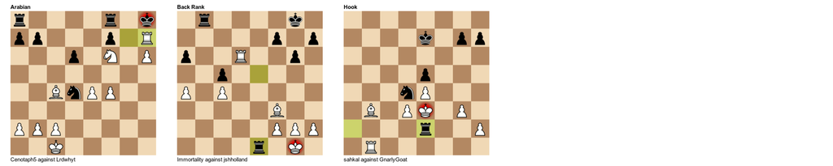